# Prediction Assignment Writeup

Robert Ruiter

24 december 2017

```r
# run on:
# Windows >= 8 x64 (build 9200)
# R version 3.4.2 (2017-09-28)
library(caret)
library(randomForest)
```

## Introduction

Using devices such as Jawbone Up, Nike FuelBand, and Fitbit it is now possible to collect a large amount of data about personal activity relatively inexpensively. These type of devices are part of the quantified self movement - a group of enthusiasts who take measurements about themselves regularly to improve their health, to find patterns in their behavior, or because they are tech geeks. One thing that people regularly do is quantify how much of a particular activity they do, but they rarely quantify how well they do it. In this project, the goal will be to use data from accelerometers on the belt, forearm, arm, and dumbell of 6 participants. They were asked to perform barbell lifts correctly and incorrectly in 5 different ways. More information is available from the website here: [Human Activity Recognition](http://groupware.les.inf.puc-rio.br/har). See also the license section.

## Data

The data comes in two files, a training and a testset.

```r
url1 <- "https://d396qusza40orc.cloudfront.net/predmachlearn/pml-training.csv"
url2 <- "https://d396qusza40orc.cloudfront.net/predmachlearn/pml-testing.csv"
file1 <- "data/pml-training.csv"
file2 <- "data/pml-testing.csv"

#download.file(url1, file1, mode = "wb")
#download.file(url2, file2, mode = "wb")

## read the files
dfTraining <- read.csv(file1, na.strings = c("#DIV/0!", "NA"), strip.white = TRUE)
dfTesting <- read.csv(file2, na.strings = c("#DIV/0!", "NA"), strip.white = TRUE)
```

Check if the two sets are equal in variables:

```r
setdiff(colnames(dfTraining), colnames(dfTesting))
```

```
## [1] "classe"
```

```r
setdiff(colnames(dfTesting), colnames(dfTraining))
```

```
## [1] "problem_id"
```

Variable **classe** is missing in the testdata, whereas **problem_id** is missing in the trainingset.

Remove *NA* variables and first 7 variables from the testset. Then select the same variables in the trainingset as in the testset:

```r
dfTesting <- dfTesting[, -c(1:7)]
dfTesting <- dfTesting[, colSums(is.na(dfTesting)) == 0]

cols <- names(subset(dfTesting, select = -c(problem_id)))
dfTraining <- dfTraining[, c(cols, "classe")]

# remove unused objects:
rm(url1, url2, file1, file2, cols)
```

## Modelling

The trainingset is split into a training and testing set. For reproducibility we set a seed.

```r
set.seed(32145)
inTrain <- createDataPartition(y = dfTraining$classe, p = .7, list = FALSE)
training <- dfTraining[inTrain, ]
testing <- dfTraining[-inTrain, ]
dim(training);dim(testing)
```

```
## [1] 13737    53
```

```
## [1] 5885   53
```

Create a K-nearest and a random forest model, for we can evaluate which is a better predictor. To avoid overfitting do cross validation for both models.

```r
trainCtr <- trainControl(method = "repeatedcv", number = 10, repeats = 3)
modelKnn <- train(classe ~ ., data = training,
                  method = "knn", trControl = trainCtr,
                  preProcess = c("center", "scale"), tuneLength = 10)
modelRF <- train(classe ~ ., data = training,
                 method = "rf",
                 trControl = trainControl(method="cv"), number = 3)
```

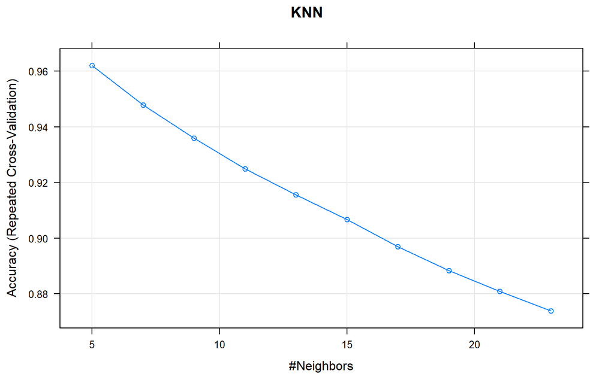

*fig 1. K-nearest*

```r
plot(modelKnn, main = "KNN")
```

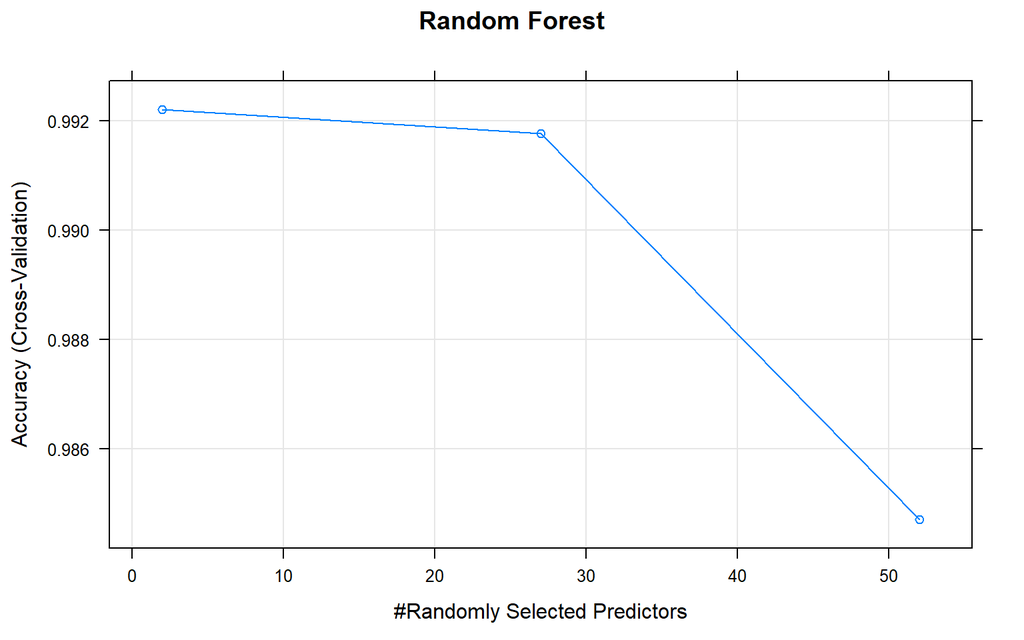

*fig 2. Random Forest*

```r
plot(modelRF, main = "Random Forest")
```

The OOB error for the random forest model is: 0.713%.

Check which model is most accurate.

```r
predKnn <- predict(modelKnn, newdata = testing)
predRF <- predict(modelRF, newdata = testing)
```

Accuracy errors:  
* KNN: 0.036  
* RF: 0.0075

The random forest model is most accurate.

## Result

With the chosen model predict on the testset.

```r
lastPred <- predict(modelRF$finalModel, newdata = dfTesting)
lastPred
```

```
##  1  2  3  4  5  6  7  8  9 10 11 12 13 14 15 16 17 18 19 20
##  B  A  B  A  A  E  D  B  A  A  B  C  B  A  E  E  A  B  B  B
## Levels: A B C D E
```